# Advanced `ggplot2` homework

# MVP

**Question 1.**

Load in the libraries you need, and look at the `backpack` data. ake note of variable names and dimensions.

```r
library(CodeClanData)
library(ggthemes)
library(scales)
library(tidyverse)
head(backpack)
```

|  | backpack_weight | body_weight | ratio | back_problems | major | year | sex | status | units |
| --- | --- | --- | --- | --- | --- | --- | --- | --- | --- |
| 1 | 9 | 125 | 0.0720000 | 1 | Bio | 3 | Female | U | 13 |
| 2 | 8 | 195 | 0.0410256 | 0 | Philosophy | 5 | Male | U | 12 |
| 3 | 10 | 120 | 0.0833333 | 1 | GRC | 4 | Female | U | 14 |
| 4 | 6 | 155 | 0.0387097 | 0 | CSC | 6 | Male | G | 0 |
| 5 | 8 | 180 | 0.0444444 | 0 | EE | 2 | Female | U | 14 |
| 6 | 5 | 240 | 0.0208333 | 0 | History | 0 | Male | G | 0 |

```r
str(backpack)
```

```
## 'data.frame':    100 obs. of  9 variables:
##  $ backpack_weight: int  9 8 10 6 8 5 8 4 5 2 ...
##  $ body_weight    : int  125 195 120 155 180 240 170 185 130 120 ...
##  $ ratio          : num  0.072 0.041 0.0833 0.0387 0.0444 ...
##  $ back_problems  : int  1 0 1 0 0 0 0 1 0 0 ...
##  $ major          : Factor w/ 41 levels "Act.","Aero",..: 9 32 19 16 18 20 13 7 9 9 ...
##  $ year           : int  3 5 4 6 2 0 3 5 4 5 ...
##  $ sex            : Factor w/ 2 levels "Female","Male": 1 2 1 2 1 2 2 1 1 1 ...
##  $ status         : Factor w/ 2 levels "G","U": 2 2 2 1 2 1 2 2 2 2 ...
##  $ units          : int  13 12 14 0 14 0 15 18 14 8 ...
```

```r
# Variable names
names(backpack)
```

```
## [1] "backpack_weight" "body_weight"     "ratio"           "back_problems"
## [5] "major"           "year"            "sex"             "status"
## [9] "units"
```

```r
# Dimensions
dim(backpack)
```

```
## [1] 100   9
```

```r
# backpack %>%
#  distinct(major)# %>% # Philosophy/GRC/Bio
# distinct(sex) # Female/Male
# distinct(status) # U/G
# distinct(year). # 0-6
# distinct(units) #0 -19
```

**Question 2.**

What is the distribution of backpack weights that students are carrying? Choose an appropriate graph to show the distribution.

```r
# View(backpack)
backpack %>%
  summarise(
    avg_backpack_weight = mean(backpack_weight),
    median_backpack_weight = median(backpack_weight),
    min_backpack_weight = min(backpack_weight),
    max_backpack_weight = max(backpack_weight)
  )
```

| avg_backpack_weight | median_backpack_weight | min_backpack_weight | max_backpack_weight |
| --- | --- | --- | --- |
| 11.66 | 11 | 2 | 35 |

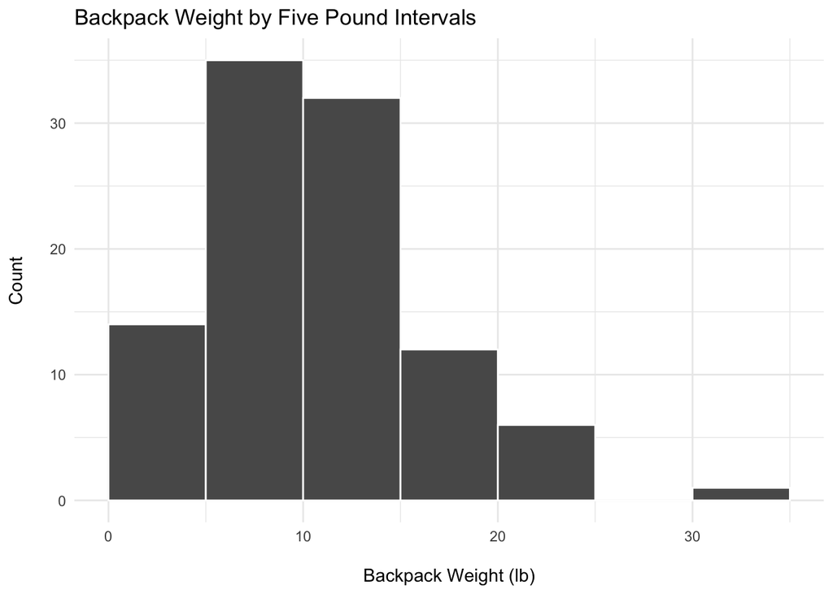

```r
backpack %>%
  ggplot(aes(x = backpack_weight)) +
  geom_histogram(binwidth = 5, col = "white", boundary = 5) +
  theme_minimal() +
  labs(
    x = "\nBackpack Weight (lb)",
    y = "Count\n",
    title = "Backpack Weight by Five Pound Intervals"
  )
```

**Question 3.**

Are there differences in backpack weight between sex?

```r
backpack %>%
  select(sex, backpack_weight) %>%
  group_by(sex) %>%
  summarise(
    count = n(),
    avg_backpack_weight = mean(backpack_weight)
  ) %>%
  ungroup()
```

| sex | count | avg_backpack_weight |
| --- | --- | --- |
| Female | 55 | 11.03636 |
| Male | 45 | 12.42222 |

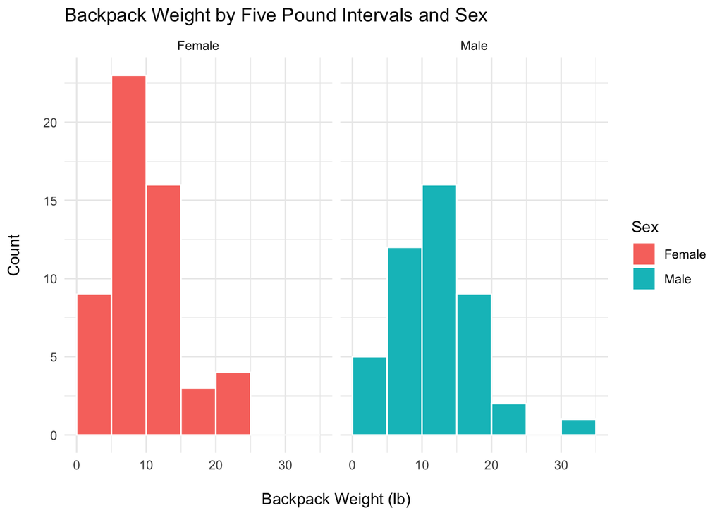

```r
backpack %>%
  ggplot(aes(x = backpack_weight, fill = sex)) +
  geom_histogram(binwidth = 5, col = "white", boundary = 5) +
  facet_wrap(~sex) +
  theme_minimal() +
  labs(
    x = "\nBackpack Weight (lb)",
    y = "Count\n",
    title = "Backpack Weight by Five Pound Intervals and Sex",
    fill = "Sex"
  )
```

- There are more females (55) than males (45).
- Average backpack weight for females is 11.04 lb.
- Average backpack weight for males is 12.42 lb.
- More males carry backpacks in the 15-20 lb range than females.
- More females carry backpacks in the 20-25 lb range than males.
- Most common backpack weight for females is> 5 lb < 10 lb.
- Most common backpack weight for males is > 10 lb < 15 lb.

**Question 4.**

What is the relationship between body weight and backpack weight?

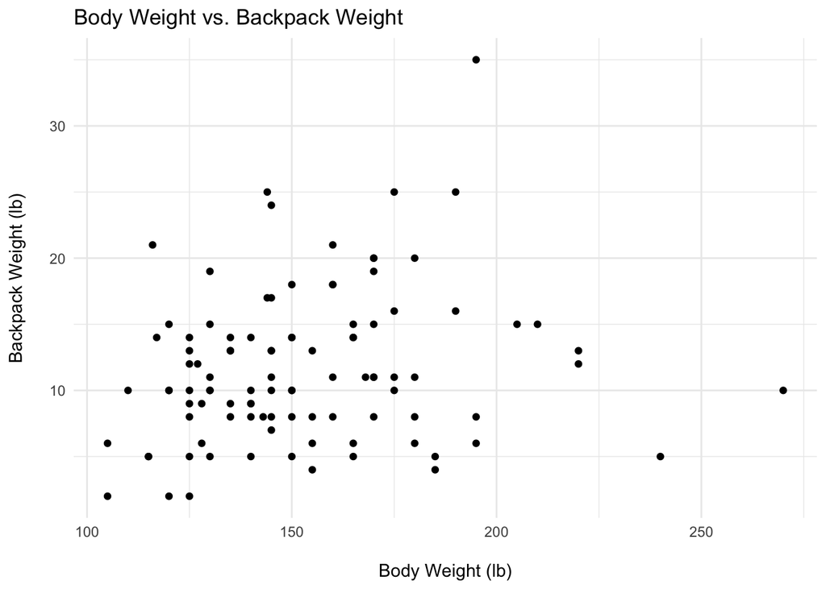

```r
backpack %>%
  ggplot(aes(
    x = body_weight,
    y = backpack_weight
  )) +
  geom_point() +
  theme_minimal() +
  labs(
    x = "\nBody Weight (lb)",
    y = "Backpack Weight (lb)\n",
    title = "Body Weight vs. Backpack Weight"
  )
```

There is no clear overall pattern, as body weight increases backpack weights are mostly distributed fairly evenly above or below body weights. Individual strength would appear more relevant than body weight.

**Question 5.**

Is this relationship different between men and women? Choose an appropriate plot and interpret your findings.

```r
backpack %>%
  mutate(backpack_bodyweight_percent = backpack_weight / body_weight) %>%
  select(backpack_bodyweight_percent, sex) %>%
  group_by(sex) %>%
  summarise(avg_backpack_bodyweight_percent =
              mean(backpack_bodyweight_percent) * 100) %>%
  ungroup()
```

| sex | avg_backpack_bodyweight_percent |
| --- | --- |
| Female | 8.057685 |
| Male | 7.290711 |

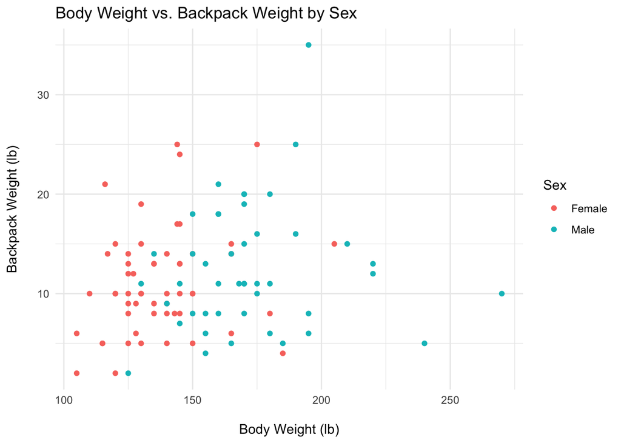

```r
backpack %>%
  ggplot( aes(
    x = body_weight,
    y = backpack_weight,
    colour = sex
  )) +
  geom_point() +
  theme_minimal() +
  labs(
    x = "\nBody Weight (lb)",
    y = "Backpack Weight (lb)\n",
    title = "Body Weight vs. Backpack Weight by Sex",
    colour = "Sex"
  )
```

- There is a wider spread of results for male than female.
- There is more clustering of females under 150 lb in body weight and < 15 lb backpack.
- Females on average carry a higher percentage of their body weight in their backpacks 8.1% female vs 7.3% males.
- One male carries the heaviest backpack and is not in the top 5 heaviest males.

**Question 6.**

What **proportion** of students report back pain?

```r
backpack %>%
  summarise(back_problems_proportion = sum(back_problems) / n())
```

| back_problems_proportion |
| --- |
| 0.32 |

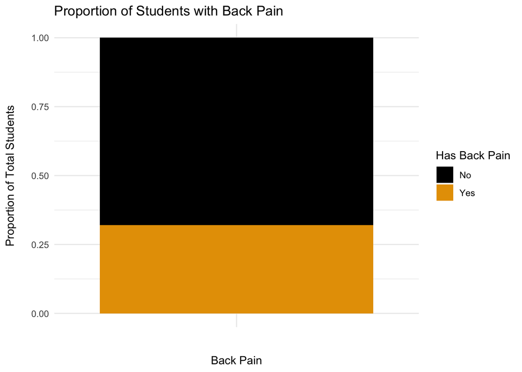

```r
backpack %>%
  mutate(back_problems = recode(back_problems, "0" = "No", "1" = "Yes")) %>%

  ggplot(aes(x = "", y=..count../sum(..count..), fill = back_problems)) +
  scale_y_continuous(labels = label_number())+
  geom_bar() +
  theme_minimal() +
  scale_fill_colorblind()+
  labs(
    x = "\nBack Pain",
    y = "Proportion of Total Students\n",
    title = "Proportion of Students with Back Pain",
    fill = "Has Back Pain"
  )
```

0.32 of Students have back pain.

**Question 7.**

Is this proportion different between men and women?

```r
backpack %>%
  group_by(sex) %>%
  summarise(back_problems_proportion = sum(back_problems) / n()) %>%
  ungroup()
```

| sex | back_problems_proportion |
| --- | --- |
| Female | 0.4363636 |
| Male | 0.1777778 |

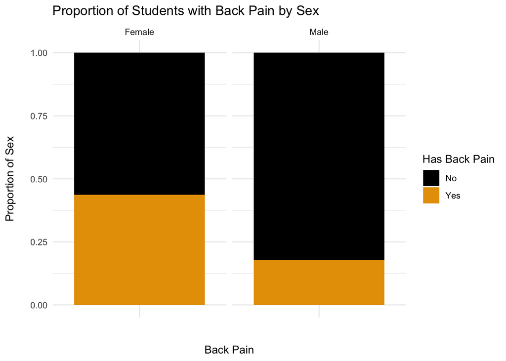

```r
backpack %>%
 mutate(back_problems = recode(back_problems, "0" = "No", "1" = "Yes")) %>%
  ggplot(aes(x = "",  y=..count../sum(..count..), fill = back_problems)) +
  scale_y_continuous(labels = label_number())+
  geom_bar(position = "fill") +
  facet_wrap(~sex) +
  theme_minimal() +
  scale_fill_colorblind()+
  labs(
    x = "\nBack Pain",
    y = "Proportion of Sex\n",
    title = "Proportion of Students with Back Pain by Sex",
    fill = "Has Back Pain"
  )
```

- 0.44 of females have back pain.
- 0.18 of males have back pain.

**Question 8.**

Now you’ve investigated your data separately, create plots to describe the relationship between backpack weight, body weight, gender and reported backpain.

Try both `backpack_weight` and `body_weight` as well as the `ratio`.

*Hint: faceting would be useful here*.

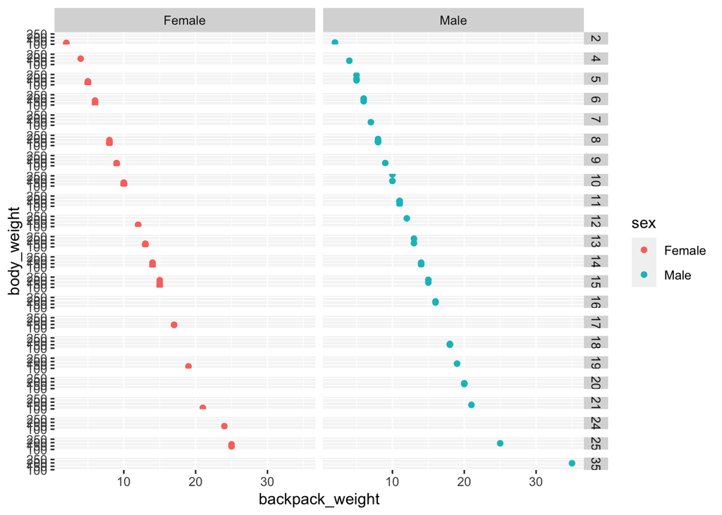

```r
backpack %>%
  ggplot(aes(x = backpack_weight, y=body_weight, colour=sex)) +
    geom_point() +
  facet_grid(backpack_weight ~ sex)
```

[figure not shown]

```r
backpack %>%
  ggplot(aes(x = backpack_weight, y=body_weight, colour=sex)) +
    geom_point() +
  facet_grid(body_weight ~ sex)
```

[figure not shown]

```r
backpack %>%
  ggplot(aes(x = backpack_weight, y = ratio, colour=sex)) +
    geom_point() +
  facet_grid(ratio ~ sex)
```

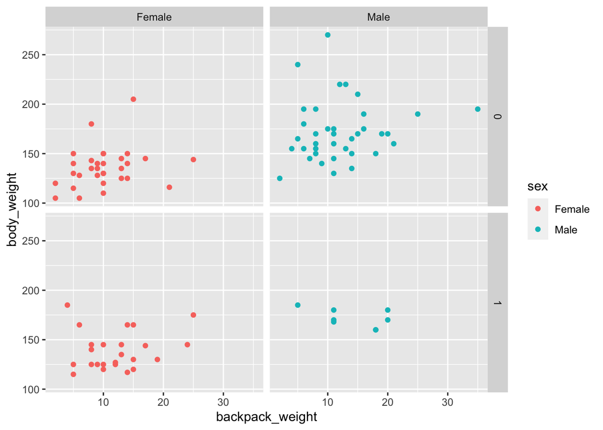

```r
backpack %>%
  ggplot(aes(x = backpack_weight, y=body_weight, colour=sex)) +
    geom_point() +
  facet_grid(back_problems ~ sex)
```

Sorry pretty lost here, too late for me.